# Riddler Classic Solution: Can You Get The Gloves Out Of The Box?

Quoc Tran

03/27/2020

### [Riddler Classic](https://fivethirtyeight.com/features/can-you-get-the-gloves-out-of-the-box/)

#### By Zach Wissner-Gross

From Chris Nho comes a question of rolling (and re-rolling) a die:

You start with a fair 6-sided die and roll it six times, recording the results of each roll. You then write these numbers on the six faces of *another*, unlabeled fair die. For example, if your six rolls were 3, 5, 3, 6, 1 and 2, then your second die wouldn’t have a 4 on it; instead, it would have two 3s.

Next, you roll this second die six times. You take those six numbers and write them on the faces of *yet another* fair die, and you continue this process of generating a new die from the previous one.

Eventually, you’ll have a die with the same number on all six faces. What is the average number of rolls it will take to reach this state?

*Extra credit*: Instead of a standard 6-sided die, suppose you have an *N*-sided die, whose sides are numbered from 1 to *N*. What is the average number of rolls it would take until all *N* sides show the same number?

## My Solution

It’s obvious that I’m going to end up doing this with Monte-Carlo experiments anyways, so we can just start off with that.

```r
dieGame <- function(nSides = 6) {
  nRolls <- 0
  currentDie <- 1:nSides
  while (length(unique(currentDie)) != 1) {
    currentDie <- sample(currentDie, nSides, replace = TRUE)
    nRolls <- nRolls + 1
  }
  return(nRolls)
}

df <- data.frame(allGames = NA, nSides = NA)
for (nSides in 6:16) {
  allGames <- c()
  for (i in 1:500) {
    allGames <- c(allGames, dieGame(nSides = nSides))
  }
  df <- rbind(df, data.frame(allGames, nSides))
}
df <- df[-1,]

print(mean(df[df$nSides == 6, "allGames"]))
```

```
## [1] 9.838
```

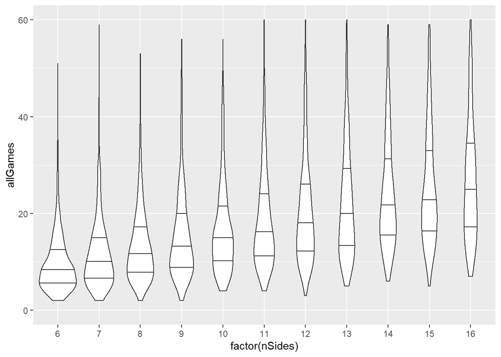

```r
library(ggplot2)
ggplot(df) +
  geom_violin(aes(x = factor(nSides), y = allGames), draw_quantiles = c(0.25, 0.5, 0.75)) +
  ylim(c(0, 60))
```